# Classification

```python
import pandas as pd
import numpy as np
from matplotlib import pyplot as plt
import seaborn as sns
```

```python
data_folder = 'C:/Users/matte/RockPaperScissorsData'

data_folder_pixel = data_folder + "/pixel_csv"
data_folder_landmarks = data_folder + "/landmarks_csv"
data_folder_distances = data_folder + "/distances_csv"
data_folder_aug_pixel = data_folder + "/augmented_pixel_csv"
data_folder_aug_landmarks = data_folder + "/augmented_landmarks_csv"
```

```python
techniques_folder = [data_folder_pixel, data_folder_landmarks,data_folder_distances,
              data_folder_aug_pixel, data_folder_aug_landmarks]
```

```python
techniques = ['pixel', 'landmarks', 'distances', 'aug_pixel', 'aug_landm', 'aug_pix_pca']
```

## Load Datasets

```python
df_list = []
for tech in techniques_folder:
    df_rock = pd.read_csv(tech + '/rock.csv', header=None)
    df_paper = pd.read_csv(tech + '/paper.csv', header=None)
    df_scissors = pd.read_csv(tech + '/scissors.csv', header=None)

    df_rock_target = df_rock.assign(target=np.full((len(df_rock), 1), 'rock'));
    df_paper_target = df_paper.assign(target=np.full((len(df_paper), 1), 'paper'));
    df_scissors_target = df_scissors.assign(target=np.full((len(df_scissors), 1), 'scissors'));

    df = pd.concat([df_rock_target, df_paper_target, df_scissors_target])

    df_list.append(df)
```

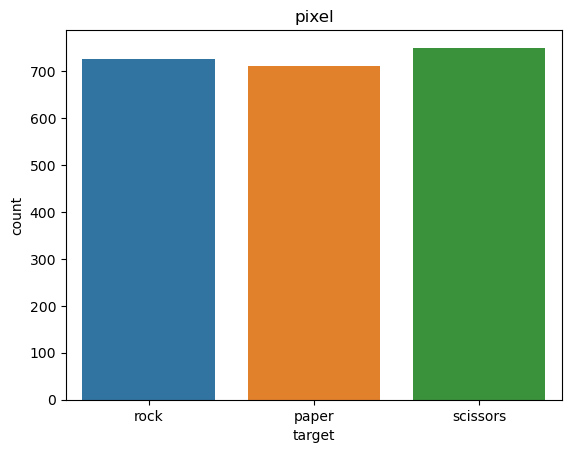

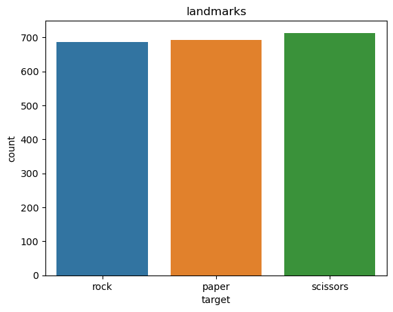

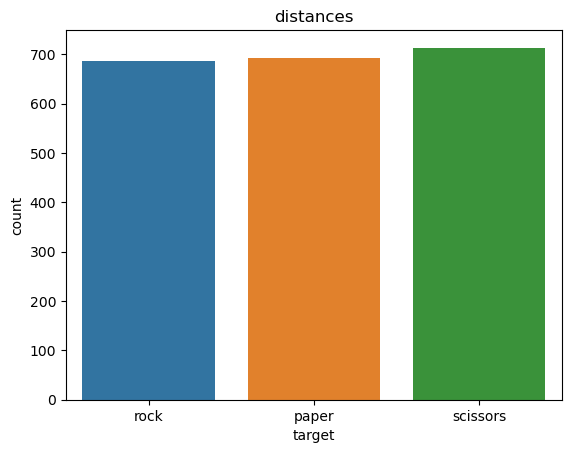

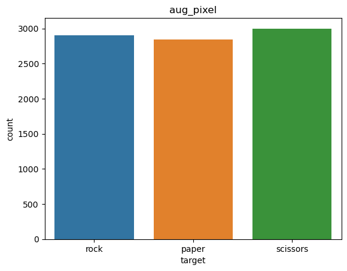

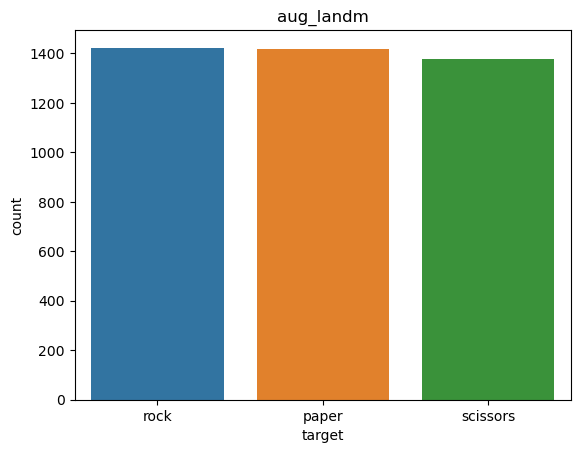

```python
count = 0
for df in df_list:
    sns.countplot(x = 'target', data = df)
    plt.title(techniques[count])
    plt.show()
    count = count + 1
```

We can see from the graphs that all 5 datasets created are quite balanced

# Classifiers

```python
from sklearn.model_selection import cross_validate, cross_val_predict
from sklearn.metrics import make_scorer, accuracy_score, f1_score, confusion_matrix, ConfusionMatrixDisplay
from sklearn.pipeline import Pipeline
from sklearn.model_selection import KFold
from sklearn.decomposition import PCA
from statistics import mean
```

```python
X_list = []
y_list = []
for df in df_list:
    X_list.append(df.drop(columns = ["target"]))
    y_list.append(df.target)
```

### PCA on Pixel-DataSet

Since there are 625 many features, it might be convenient to apply a Principal Component Analysis to reduce them.

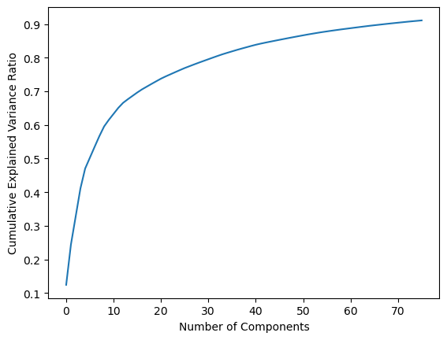

```python
df = X_list[3].copy()

pca = PCA(n_components = 0.91)
principal_components = pca.fit_transform(df)

cumulative_var_ratio = np.cumsum(pca.explained_variance_ratio_)
plt.plot(cumulative_var_ratio)
plt.xlabel('Number of Components')
plt.ylabel('Cumulative Explained Variance Ratio')
plt.show()
```

By plotting the Cumulative Explained Variance Ratio as the number of components varies, we see that with 70 components an explained variance greater than 90% is reached. So I decide to use this number of features in the pipeline

### Defining Cross-Validation

I decided to evaluate different classifiers for each dataset created. To do this I decided to use cross validation with 10 folds.

```python
def test_classifier(clf, X_list, y_list):
    pipe = Pipeline([('clf', clf)])
    pipe_pca = Pipeline([('pca', PCA(n_components = 70)), ('clf', clf)])

    kf = KFold(n_splits = 10)

    results_list = []

    #cross validation
    for count in (range(len(X_list))):
        results = cross_validate(pipe,
                        X_list[count],
                        y_list[count],
                        scoring = { 'f1_scorer': make_scorer(f1_score, average = 'macro'),
                                     'accuracy': make_scorer(accuracy_score)},
                        return_estimator = True,
                        cv = kf,
                        n_jobs = -1)

        results_list.append(results)

    #cross validation with PCA
    results = cross_validate(pipe_pca,
                        X_list[3],
                        y_list[3],
                        scoring = { 'f1_scorer': make_scorer(f1_score, average = 'macro'),
                                    'accuracy': make_scorer(accuracy_score)},
                        return_estimator = True,
                        cv = kf,
                        n_jobs = -1)

    results_list.append(results)

    return results_list

def plot_confusion_matrix(clf, X_list, y_list):
    pipe = Pipeline([('clf', clf)])
    pipe_pca = Pipeline([('pca', PCA(n_components = 70)), ('clf', clf)])

    kf = KFold(n_splits = 10)

    y_pred_list = []

    #cross validation
    for count in (range(len(X_list))):
        y_pred = cross_val_predict(pipe,
                        X_list[count],
                        y_list[count],
                        cv = kf,
                        n_jobs = -1)

        y_pred_list.append(y_pred)

    #cross validation with PCA
    y_pred = cross_val_predict(pipe_pca,
                        X_list[3],
                        y_list[3],
                        cv = kf,
                        n_jobs = -1)

    y_pred_list.append(y_pred)


    new_y_list = y_list[:]
    new_y_list.append(y_list[3])

    conf_mat_list = []
    for count in (range(len(y_pred_list))):
        conf_mat = confusion_matrix(new_y_list[count], y_pred_list[count])
        conf_mat_list.append(conf_mat)

    count = 0
    for conf_mat in conf_mat_list:
        disp = ConfusionMatrixDisplay(confusion_matrix = conf_mat,
                                display_labels = ['paper', 'rock', 'scissors'])
        print(techniques[count ])
        disp.plot()
        count = count + 1
        plt.show()

def plot_results(results_list):

    metrics_accuracy = pd.DataFrame({'pixel': results_list[0]['test_accuracy'],
                        'landmarks': results_list[1]['test_accuracy'],
                        'distances': results_list[2]['test_accuracy'],
                        'aug_pixel': results_list[3]['test_accuracy'],
                        'aug_landm': results_list[4]['test_accuracy'],
                        'aug_pix_pca': results_list[5]['test_accuracy']})

    metrics_fscore = pd.DataFrame({'pixel': results_list[0]['test_f1_scorer'],
                        'landmarks': results_list[1]['test_f1_scorer'],
                        'distances': results_list[2]['test_f1_scorer'],
                        'aug_pixel': results_list[3]['test_f1_scorer'],
                        'aug_landm': results_list[4]['test_f1_scorer'],
                        'aug_pix_pca': results_list[5]['test_f1_scorer']})

    ax = metrics_accuracy.boxplot(figsize = (8, 3.5))
    ax = metrics_accuracy.boxplot()
    ax.set_ylabel('accuracy')
    plt.show()

    ax = metrics_fscore.boxplot(figsize = (8, 3.5))
    ax = metrics_fscore.boxplot()
    ax.set_ylabel('f1_scorer')
    plt.show()


    print('Mean accuracy scores:')
    print("'pixel': ", mean(metrics_accuracy['pixel']))
    print("'landmarks': ", mean(metrics_accuracy['landmarks']))
    print("'distances': ", mean(metrics_accuracy['distances']))
    print("'aug_pixel': ", mean(metrics_accuracy['aug_pixel']))
    print("'aug_landm': ", mean(metrics_accuracy['aug_landm']))
    print("'aug_pix_pca': ", mean(metrics_accuracy['aug_pix_pca']))

    print('\nMean f1 scores:')
    print("'pixel': ", mean(metrics_fscore['pixel']))
    print("'landmarks': ", mean(metrics_fscore['landmarks']))
    print("'distances': ", mean(metrics_fscore['distances']))
    print("'aug_pixel': ", mean(metrics_fscore['aug_pixel']))
    print("'aug_landm': ", mean(metrics_fscore['aug_landm']))
    print("'aug_pix_pca': ", mean(metrics_fscore['aug_pix_pca']))

    print('\nMean score time:')
    print("'pixel': ", mean(results_list[0]['score_time']))
    print("'landmarks': ", mean(results_list[1]['score_time']))
    print("'distances': ", mean(results_list[2]['score_time']))
    print("'aug_pixel': ", mean(results_list[3]['score_time']))
    print("'aug_landm': ", mean(results_list[4]['score_time']))
    print("'aug_pix_pca': ", mean(results_list[5]['score_time']))
```

For each classifier I represent the boxplots of the accuracy and f1 score. Furthermore, I report the confusion matrix to verify if the classifier gets confused between two classes more than the other.

## Decision Tree

### criterion = gini

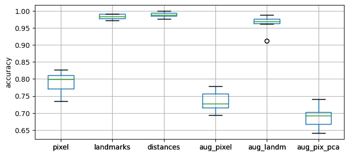

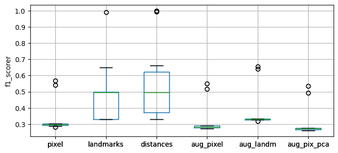

```
Mean accuracy scores:
'pixel':  0.7916069708013909
'landmarks':  0.9832581453634085
'distances':  0.989002050580998
'aug_pixel':  0.7326386170906719
'aug_landm':  0.966342830768538
'aug_pix_pca':  0.6870454011741682

Mean f1 scores:
'pixel':  0.3465351483038297
'landmarks':  0.49464435986536404
'distances':  0.5635999894086929
'aug_pixel':  0.33100511088293055
'aug_landm':  0.3916377987050869
'aug_pix_pca':  0.3183828563020796

Mean score time:
'pixel':  0.019704318046569823
'landmarks':  0.01070103645324707
'distances':  0.009600996971130371
'aug_pixel':  0.034405755996704104
'aug_landm':  0.01040201187133789
'aug_pix_pca':  0.06240460872650146
```

```python
from sklearn.tree import DecisionTreeClassifier
decisionTree_gini = DecisionTreeClassifier(criterion = 'gini')

results_list = test_classifier(decisionTree_gini, X_list, y_list);
plot_results(results_list)
```

```
pixel
```

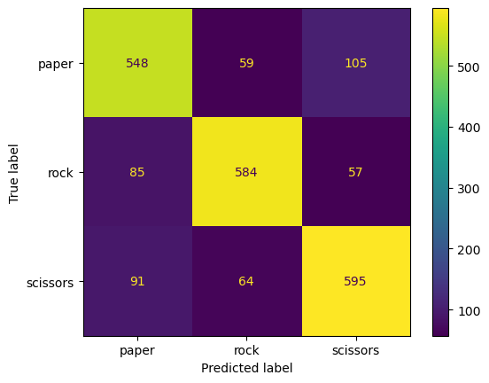

```
landmarks
```

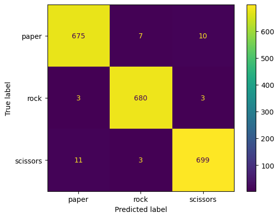

```
distances
```

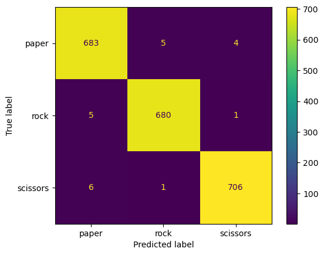

```
aug_pixel
```

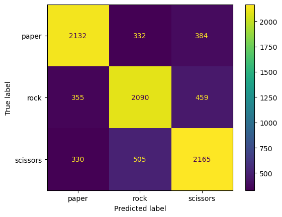

```
aug_landm
```

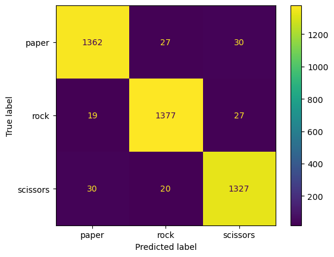

```
aug_pix_pca
```

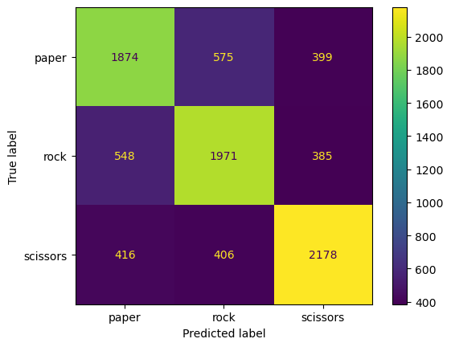

```python
plot_confusion_matrix(decisionTree_gini, X_list, y_list)
```

## Decision Tree

### criterion = entropy

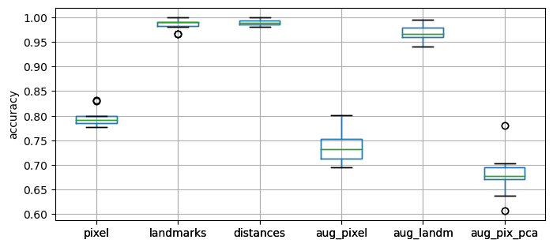

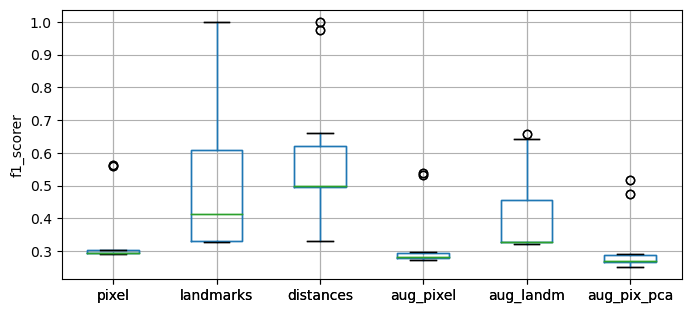

```
Mean accuracy scores:
'pixel':  0.7970843282644212
'landmarks':  0.9856459330143541
'distances':  0.989002050580998
'aug_pixel':  0.735034703196347
'aug_landm':  0.9682368767659939
'aug_pix_pca':  0.6816819308545335

Mean f1 scores:
'pixel':  0.34898227919467883
'landmarks':  0.5282076186702643
'distances':  0.5787248616913222
'aug_pixel':  0.33200133695487827
'aug_landm':  0.4088008785445922
'aug_pix_pca':  0.3147344254378342

Mean score time:
'pixel':  0.020502114295959474
'landmarks':  0.008600616455078125
'distances':  0.022697877883911134
'aug_pixel':  0.03560385704040527
'aug_landm':  0.00960087776184082
'aug_pix_pca':  0.05430335998535156
```

```python
from sklearn.tree import DecisionTreeClassifier
decisionTree_entropy = DecisionTreeClassifier(criterion = 'entropy')

results_list = test_classifier(decisionTree_entropy, X_list, y_list);
plot_results(results_list)
```

```
pixel
```

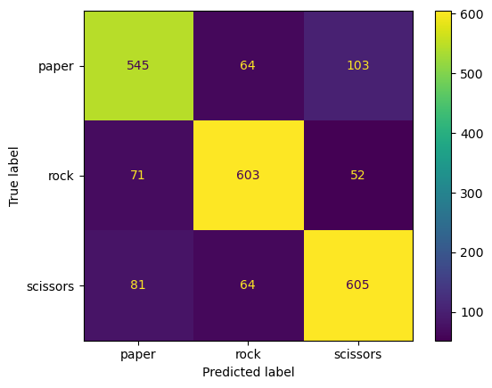

```
landmarks
```

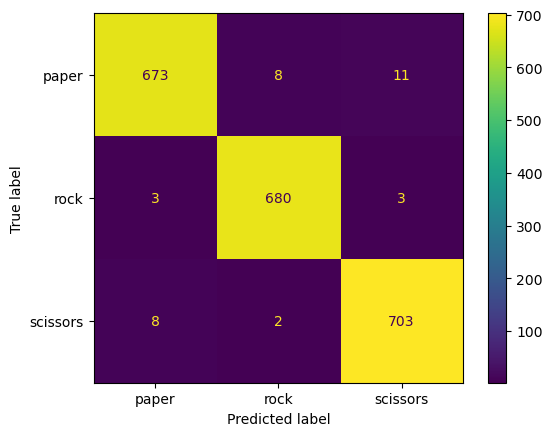

```
distances
```

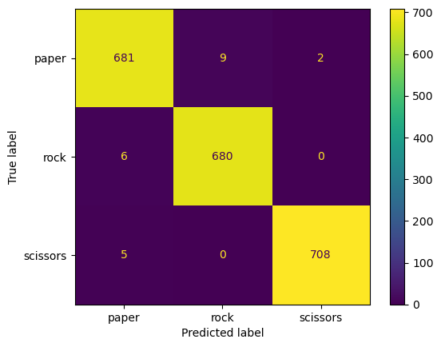

```
aug_pixel
```

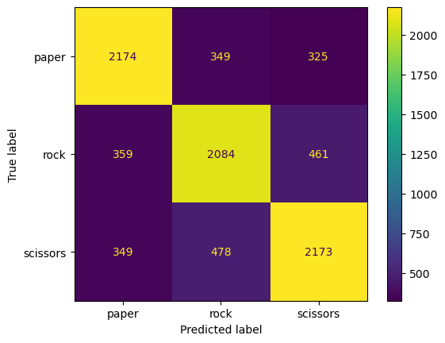

```
aug_landm
```

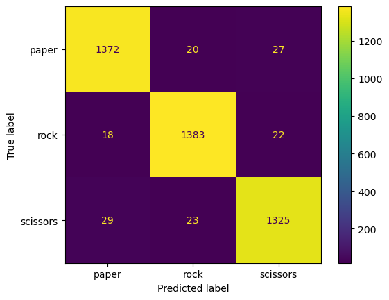

```
aug_pix_pca
```

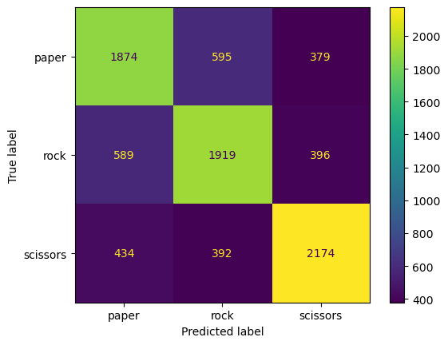

```python
plot_confusion_matrix(decisionTree_entropy, X_list, y_list)
```